# scRNASeq - Seurat

Brandon Hancock

1/26/2021

This page shows how the Seurat analysis was done for this paper

Analysis largely derived from the Seurat [vignettes](https://satijalab.org/seurat/v3.2/pbmc3k_tutorial.html)

Load the required R packages:

```r
library(dplyr)
library(Seurat)
library(patchwork)
library(progress)
library(ggplot2)
library(stringr)
```

Load scRNA seq data from 10x cellranger file, create Seurat Object. The 10x file is the result of running cellranger aggr on our Uninjured and 7D after Injury samples

```r
treg.data <- Read10X(data.dir = "C:/Users/bh719/Dropbox (Partners HealthCare)/Sally and Jim/FeiData of scRNAseq  Treg project/10xProcessedData of day 7 after burn/GenomeSeq/outs/filtered_feature_bc_matrix")

treg <- CreateSeuratObject(counts = treg.data,project = 'treg7day',min.cells = 3, min.features = 200)
```

We begin by filtering out low quality cells, see Seurat vignette for more details

```r
treg[["percent.mt"]] <- PercentageFeatureSet(treg, pattern = "^mt-")
```

Visualize cutoffs

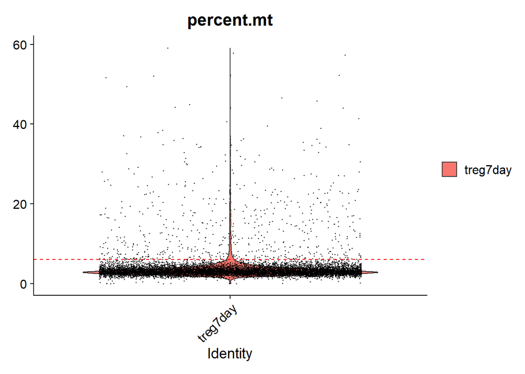

```r
VlnPlot(treg, features = c("percent.mt")) + geom_hline(yintercept = 6, linetype="dashed", color = "red")
```

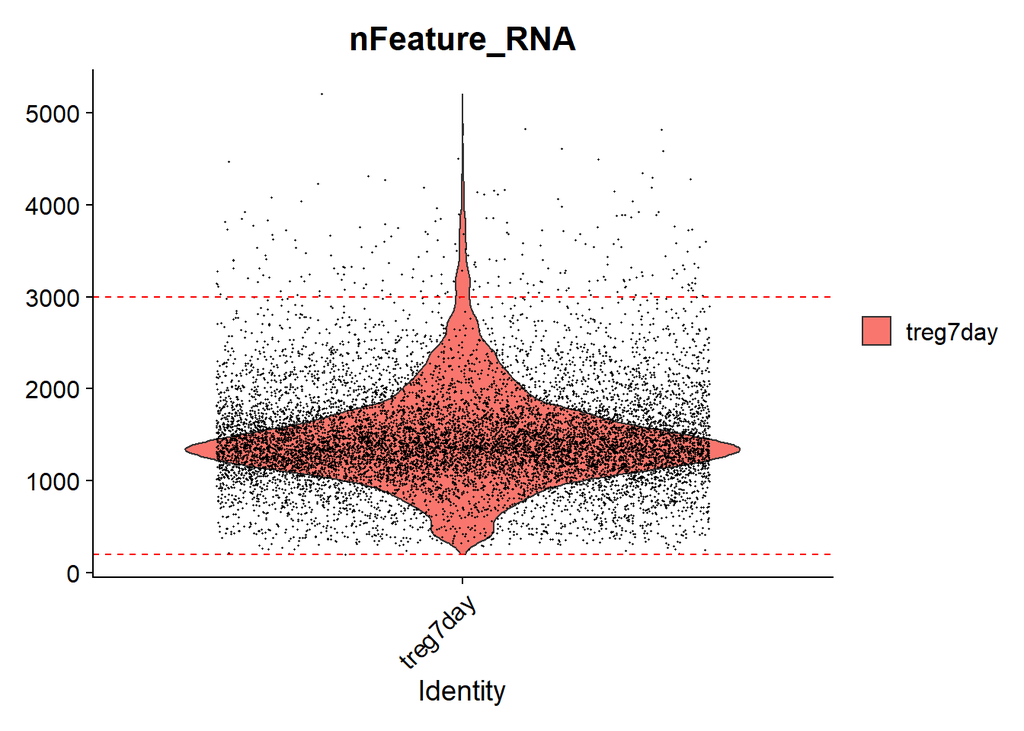

```r
#lower cutoff actually 200, not 201, but 200 gives error on plot
VlnPlot(treg, features = c("nFeature_RNA")) + geom_hline(yintercept = 201, linetype="dashed", color = "red") + geom_hline(yintercept = 3000, linetype="dashed", color = "red")
```

```r
treg <- subset(treg, subset = nFeature_RNA > 200 & nFeature_RNA < 3000 & percent.mt < 6)
```

Normalize

```r
treg <- NormalizeData(treg)
```

Identify variable features, plot with top 25 labeled

```r
treg <- FindVariableFeatures(treg, selection.method = "vst", nfeatures = 2000)

top25 <- head(VariableFeatures(treg), 25)

plot1 <- VariableFeaturePlot(treg)
plot1 <- LabelPoints(plot = plot1, points = top25, repel = TRUE)
```

```
## When using repel, set xnudge and ynudge to 0 for optimal results
```

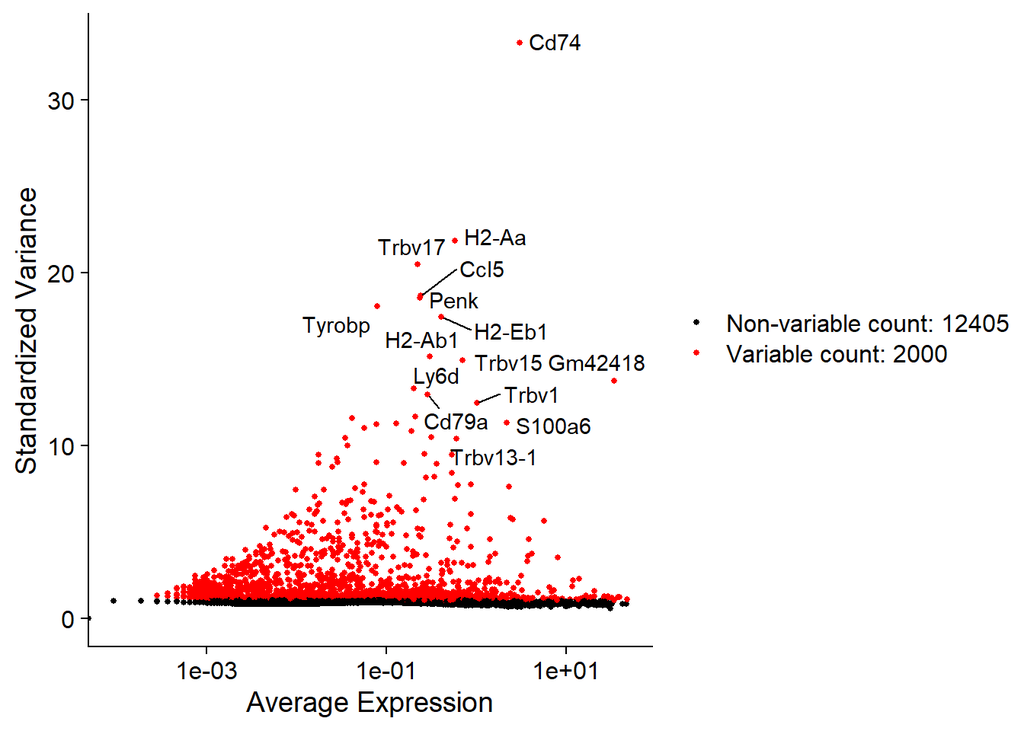

```r
plot1
```

Scale the data and run PCA

```r
all.genes <- rownames(treg)
treg <- ScaleData(treg, features = all.genes)
#PCA
treg <- RunPCA(treg, features = VariableFeatures(object = treg))
```

```
## PC_ 1
## Positive:  Rpl13, Rps20, Rps19, Rpl35, Rps26, Rpl10a, Rps2, Rpl32, Bcl2, Rps18
##     Rpl15, Rplp0, Eef1a1, Rpl12, Rpl36a, Rpl28, Rpsa, Ccr7, Rpl3, Ly6c1
##     Rplp1, Igfbp4, Sell, Klf2, Satb1, Ms4a4b, Npm1, Rps6, Gm2682, Actn1
## Negative:  S100a6, Icos, S100a11, S100a4, Tigit, Maf, S100a10, Glrx, Itgae, Lgals1
##     Smco4, Capg, Srgn, Tnfrsf1b, Ctla4, Ccr2, Prr13, Ahnak, Klrg1, Tnfrsf4
##     Ikzf2, Rora, Pglyrp1, Rilpl2, AW112010, Psen2, Ttc39c, Tnfrsf18, Itm2c, Ndfip1
## PC_ 2
## Positive:  H2-Ab1, H2-Aa, H2-Eb1, Cd79a, H2-DMb2, Iglc2, Iglc3, Ms4a1, Ly6d, Ebf1
##     Fcmr, Napsa, Mef2c, Ly86, Fcer2a, Tnfrsf13c, Cd19, Cd79b, Bank1, Mzb1
##     Siglecg, Ctsh, Cd74, Igkc, Ighd, Blnk, Cd24a, Blk, Syk, Lyn
## Negative:  Ms4a4b, Rgs10, Izumo1r, Thy1, Rplp0, Trbc2, Cd5, Il2rb, Smc4, Il2ra
##     Ccnd2, Tmsb4x, Ldha, Ifi27l2a, Slfn1, Rpl15, Nsg2, Rgs1, Cd6, Rps18
##     Rplp1, AW112010, Ass1, Socs1, Eef1a1, Rpl32, Tnfrsf18, H2afz, Rpsa, Bcl2
## PC_ 3
## Positive:  Hsp90ab1, Mif, Eif5a, Srm, Tnfrsf9, Ptma, Nhp2, Eif4a1, Pa2g4, Npm1
##     Tnfrsf4, Apex1, Ncl, C1qbp, Rps2, Hspe1, Atp5g1, Ran, Marcksl1, Shmt1
##     Tuba1b, Fbl, Ccr8, Nop16, Set, Srsf2, Nop58, Hspd1, Ranbp1, Phb
## Negative:  Klf2, Malat1, Tsc22d3, Samhd1, Ccr2, Ly6a, Tmsb4x, Ighm, Selenop, Crip1
##     Ifngr1, Fgl2, S1pr1, Rflnb, Ifi209, S100a6, S1pr4, 2810474O19Rik, Glrx, Arl4c
##     Il7r, Cd7, Vim, Ms4a4b, Rasgrp2, Lsp1, Myo1f, S100a4, Ahnak, Socs3
## PC_ 4
## Positive:  Stmn1, Birc5, Pclaf, Ube2c, Cdca3, Ccnb2, Cdca8, Spc24, Ccna2, Mki67
##     Rrm2, Tk1, Cenpm, Cks1b, Asf1b, Tpx2, Rplp0, Hmgb2, Crip1, Top2a
##     Tmsb4x, Cenpe, Cdkn3, Clspn, Hist1h2ag, Gm4316, Cenpf, Rad51, Vim, Tacc3
## Negative:  Zfp36l1, Cd83, Tnfrsf9, Tnfrsf4, Bcl2a1b, Ccr8, Nfkbid, Malat1, Ltb, Nr4a1
##     Nfkbia, Pdcd1, Rgs16, Ephx1, Orai1, Dusp1, Izumo1r, Marcksl1, Relb, Bcl2a1d
##     Rel, Nr4a3, Hivep3, Cd82, Egr2, Egr1, Tbc1d4, Junb, Ier5, Rilpl2
## PC_ 5
## Positive:  Ly6a, Actb, Srm, Ppia, Ly6c1, Ccr2, Gzmb, Eif5a, Crip1, C1qbp
##     Slc7a5, Psme2, Ldha, Pfn1, Hnrnpab, Ranbp1, Hspa9, Timm8a1, Mat2a, S100a6
##     Klrg1, S100a4, Cfl1, Nme2, Fgl2, Apex1, Nolc1, Klf2, Ltb4r1, Gnl3
## Negative:  Rps12, Izumo1r, Eef1a1, Rgs10, Rps26, Mxd4, Rpl32, Rplp1, Capn3, Tbc1d4
##     Nrp1, Gm10076, Rpl28, Rpl3, Rps18, Nsg2, Ephx1, Rpsa, Sh2d1a, Cst7
##     Rpl15, Rpl36a, Smpdl3a, Tiam1, Rpl22l1, Gsta4, 2310001H17Rik, Smc4, Rplp0, H2-Oa
```

Cluster

```r
#set nn.method to match default of older version of Seurat, used for the original analysis
treg <- FindNeighbors(treg, dims = 1:20, nn.method = 'rann')
treg <- FindClusters(treg, resolution = .5)
```

```
## Modularity Optimizer version 1.3.0 by Ludo Waltman and Nees Jan van Eck
##
## Number of nodes: 10754
## Number of edges: 335631
##
## Running Louvain algorithm...
## Maximum modularity in 10 random starts: 0.8201
## Number of communities: 11
## Elapsed time: 1 seconds
```

Run TSE dimension reduction

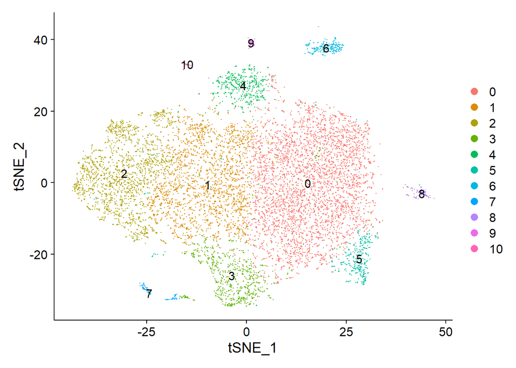

```r
treg <- RunTSNE(treg,dims = 1:20)
DimPlot(treg, reduction = "tsne", label = TRUE)
```

We found that cluster 6 expressed B cell markers (Cd74, Cd79, Ms4a1)

```r
cluster6.markers <- FindMarkers(treg,ident.1 = 6, min.pct = 0.25)
cluster6.markers <- cluster6.markers[order(cluster6.markers$avg_log2FC,decreasing = TRUE),]
head(cluster6.markers, n = 25)
```

```
##                   p_val avg_log2FC pct.1 pct.2     p_val_adj
## Cd74      2.341629e-247   6.730075 1.000 0.256 3.373117e-243
## H2-Aa      0.000000e+00   6.099423 1.000 0.006  0.000000e+00
## H2-Eb1     0.000000e+00   5.652429 1.000 0.006  0.000000e+00
## Cd79a      0.000000e+00   5.473624 0.996 0.004  0.000000e+00
## H2-Ab1     0.000000e+00   5.182138 1.000 0.004  0.000000e+00
## Ly6d       0.000000e+00   4.442344 0.958 0.009  0.000000e+00
## Cd79b      0.000000e+00   4.252908 0.996 0.075  0.000000e+00
## Iglc2      0.000000e+00   4.081123 0.941 0.001  0.000000e+00
## H2-DMb2    0.000000e+00   3.760784 0.949 0.002  0.000000e+00
## Iglc3      0.000000e+00   3.559840 0.899 0.002  0.000000e+00
## Ms4a1      0.000000e+00   3.513536 0.916 0.001  0.000000e+00
## Fcmr       0.000000e+00   3.470379 0.882 0.005  0.000000e+00
## Ebf1       0.000000e+00   3.367828 0.886 0.001  0.000000e+00
## Igkc       0.000000e+00   3.133688 0.802 0.016  0.000000e+00
## Fcer2a     0.000000e+00   3.007690 0.743 0.000  0.000000e+00
## Mef2c      0.000000e+00   2.799330 0.738 0.002  0.000000e+00
## Napsa      0.000000e+00   2.694535 0.776 0.004  0.000000e+00
## Tnfrsf13c  0.000000e+00   2.685107 0.747 0.003  0.000000e+00
## H2-Ob      0.000000e+00   2.649671 0.819 0.092  0.000000e+00
## Bank1      0.000000e+00   2.586403 0.726 0.010  0.000000e+00
## H2-Oa     4.976740e-303   2.469849 0.776 0.086 7.168994e-299
## Ighd       0.000000e+00   2.397227 0.667 0.007  0.000000e+00
## H2-DMa    3.248798e-233   2.396531 0.823 0.137 4.679893e-229
## Cd19       0.000000e+00   2.389981 0.675 0.000  0.000000e+00
## Ly86       0.000000e+00   2.342533 0.692 0.002  0.000000e+00
```

Remove cluster 6

```r
treg <- subset(treg, subset = seurat_clusters != 6)
```

Redo Variable Features

```r
treg <- FindVariableFeatures(treg, selection.method = "vst", nfeatures = 2000)
```

Send top 2000 features (genes) to text file for [Metascape](https://metascape.org/gp/index.html#/main/step1) gene ontology analysis

```r
top2000 <- head(VariableFeatures(treg), 2000)
sink("sc2000.txt")
writeLines(unlist(lapply(top2000, paste, collapse=" ")))
sink()
```

Redo Clustering (set resolution high to increase granularity of clusters for later)

```r
treg <- RunPCA(treg, features = VariableFeatures(object = treg))
```

```
## PC_ 1
## Positive:  Rpl13, Rps20, Rps19, Rpl35, Rps26, Rpl10a, Rps2, Rpl32, Bcl2, Rps18
##     Rpl15, Rplp0, Eef1a1, Rpl12, Rpl36a, Rpsa, Rpl28, Ccr7, Rpl3, Ly6c1
##     Igfbp4, Rplp1, Ms4a4b, Sell, Klf2, Satb1, Npm1, Rps6, Gm2682, Actn1
## Negative:  S100a6, Icos, S100a11, S100a4, Tigit, Maf, Glrx, S100a10, Itgae, Lgals1
##     Capg, Smco4, Srgn, Tnfrsf1b, Ccr2, Ctla4, Prr13, Ahnak, Klrg1, Tnfrsf4
##     Rora, Pglyrp1, Rilpl2, Ikzf2, Ttc39c, Psen2, AW112010, Myo1f, Gna15, Ptprcap
## PC_ 2
## Positive:  Klf2, Malat1, Tsc22d3, Samhd1, Ccr2, Ly6a, Tmsb4x, Ighm, Selenop, Crip1
##     Ifngr1, Fgl2, S1pr1, Rflnb, Ifi209, S100a6, 2810474O19Rik, S1pr4, Glrx, Il7r
##     Cd7, Arl4c, Kif21b, Rasgrp2, Myo1f, Ahnak, Lsp1, Vim, Socs3, S100a4
## Negative:  Mif, Eif5a, Hsp90ab1, Srm, Tnfrsf9, Ptma, Nhp2, Eif4a1, Pa2g4, Tnfrsf4
##     C1qbp, Npm1, Ncl, Apex1, Rps2, Atp5g1, Ran, Hspe1, Shmt1, Marcksl1
##     Tuba1b, Fbl, Ccr8, Nop16, Set, Srsf2, Nop58, Hspd1, Ranbp1, Nme2
## PC_ 3
## Positive:  Stmn1, Birc5, Pclaf, Ube2c, Cdca3, Ccnb2, Cdca8, Spc24, Ccna2, Mki67
##     Tk1, Rrm2, Cenpm, Cks1b, Asf1b, Tpx2, Hmgb2, Rplp0, Top2a, Crip1
##     Clspn, Cdkn3, Hist1h2ag, Cenpe, Cenpf, Gm4316, Rad51, Cdk1, Tmsb4x, Tacc3
## Negative:  Zfp36l1, Tnfrsf9, Cd83, Tnfrsf4, Bcl2a1b, Ccr8, Nfkbid, Ltb, Malat1, Nfkbia
##     Nr4a1, Rgs16, Pdcd1, Orai1, Ephx1, Izumo1r, Dusp1, Relb, Marcksl1, Bcl2a1d
##     Cd82, Hivep3, Nr4a3, Rel, Rilpl2, Egr2, Egr1, Junb, Tbc1d4, Mir155hg
## PC_ 4
## Positive:  Izumo1r, Rps12, Eef1a1, Nrp1, Rps26, Mxd4, Rpl32, Capn3, Tbc1d4, Rplp1
##     Gm10076, Nsg2, Sh2d1a, Ephx1, Rpl3, Rpl28, Rps18, Rpsa, Cst7, Smpdl3a
##     Tiam1, Rpl15, Smc4, Rpl22l1, Rpl36a, 2310001H17Rik, Gsta4, Ikzf2, Itgb1, Slamf6
## Negative:  Ly6a, Srm, Ccr2, Actb, Ppia, Ly6c1, Gzmb, Eif5a, Crip1, C1qbp
##     Slc7a5, S100a6, Lgals3, S100a4, Klrg1, Fgl2, Psme2, Hspa9, Timm8a1, Ltb4r1
##     Ranbp1, Hnrnpab, Mat2a, Ldha, Nme2, Pfn1, Cxcr6, Nolc1, Apex1, Cfl1
## PC_ 5
## Positive:  Stmn1, Pclaf, Fcer1g, Tyrobp, Spc24, Asf1b, Birc5, Cdca8, Tk1, Rrm2
##     Pdcd1, Ctsh, Ccna2, Tyms, Marcksl1, Tpx2, Cdca3, Cd81, Clspn, Rad51
##     Cd68, Ccnb2, Alox5ap, Csf2rb, Cdk1, Nusap1, Il1r2, Cenps, Cks1b, Cd74
## Negative:  Ifit1, Ifit3, Rtp4, Isg15, Zbp1, Stat1, Ifit3b, Samhd1, Igtp, Ifi203
##     Ifi47, Irf7, Tgtp2, Ifi27l2a, Usp18, Rpl12, Rps18, Rpl32, Rps12, Rps6
##     Ms4a4b, Bst2, Rplp1, Xaf1, Isg20, Iigp1, Mndal, Slfn1, Gbp7, Rsad2
```

```r
treg <- FindNeighbors(treg, dims = 1:25)
treg <- FindClusters(treg, resolution = 2.0)
```

```
## Modularity Optimizer version 1.3.0 by Ludo Waltman and Nees Jan van Eck
##
## Number of nodes: 10517
## Number of edges: 329902
##
## Running Louvain algorithm...
## Maximum modularity in 10 random starts: 0.6877
## Number of communities: 25
## Elapsed time: 1 seconds
```

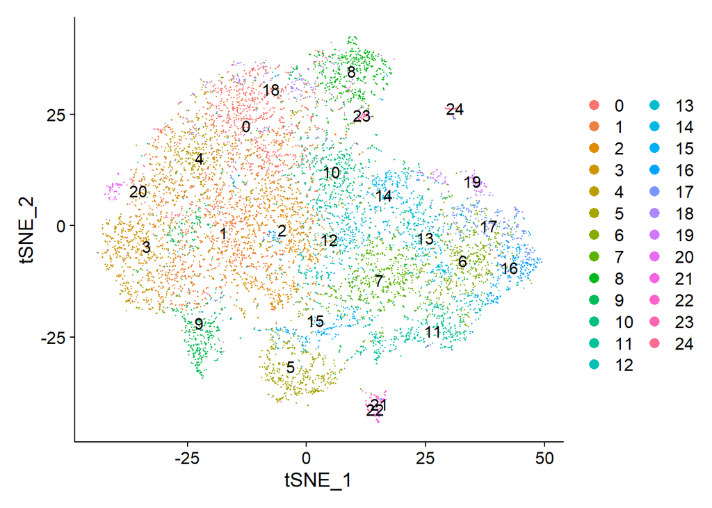

```r
treg <- RunTSNE(treg,dims = 1:10)
DimPlot(treg, reduction = "tsne", label = TRUE)
```

Define functions to add vdj metadata (alpha beta tcr clonotype) and Expanded or NonExpanded classification to cells Function builds on this [post](https://www.biostars.org/p/383217/)

```r
add_clonotype <- function(tcr_folder, seurat_obj){
  tcr <- read.csv(paste(tcr_folder,"filtered_contig_annotations.csv", sep=""))
  tcr <- tcr[!duplicated(tcr$barcode), ]

  tcr <- tcr[,c("barcode", "raw_clonotype_id")]
  names(tcr)[names(tcr) == "raw_clonotype_id"] <- "clonotype_id"

  clono <- read.csv(paste(tcr_folder,"clonotypes.csv", sep=""))

  tcr <- merge(tcr, clono[, c("clonotype_id", "cdr3s_aa")])

  tcr <- tcr[, c(2,1,3)]
  rownames(tcr) <- tcr[,1]
  tcr[,1] <- NULL

  clono_seurat <- AddMetaData(object=seurat_obj, metadata=tcr)

  clone_counts <- f_clone_counts(clono_seurat)
  cell_state <- data.frame("Cell State" = c())
  pb <- progress_bar$new(total = length(clono_seurat$clonotype_id))
  for (i in 1:length(clono_seurat$clonotype_id)){
    clonotype_id <- clono_seurat$clonotype_id[[i]]
    cell <- names(clono_seurat$clonotype_id)[[i]]
    pb$tick()
    if (is.na(clonotype_id)){
      cell_state <- rbind(cell_state, data.frame("Cell State" = 'Non Expanded'))
      next
    }
    count <- clone_counts[which(clone_counts$clones == clonotype_id),]$count
    if (count > 1){
      cell_state <- rbind(cell_state, data.frame("Cell State" = 'Expanded'))
    } else {
      cell_state <- rbind(cell_state, data.frame("Cell State" = 'Non Expanded'))
    }
  }
  rownames(cell_state) <- names(clono_seurat$clonotype_id)
  clono_seurat <- AddMetaData(object = clono_seurat, metadata = cell_state)

  return(clono_seurat)
}

f_clone_counts <- function(seurat_object){
  clones <- seurat_object@meta.data$clonotype_id
  clone_counts <- data.frame(clones = c(),count = c())
  for (i in 1:length(clones)){
    c <- clones[[i]]
    if (! clones[[i]] %in% clone_counts$clones){
      clone_counts <- rbind(clone_counts,data.frame(clones = clones[[i]],count = 1))
    } else {
      clone_counts[which(clone_counts$clone == c),]$count <- clone_counts[which(clone_counts$clone == c),]$count + 1
    }
  }
  clone_counts <- clone_counts[order(clone_counts$count, decreasing = TRUE),]
  return(clone_counts)
}
```

Add vdj data and plot

[output not shown]

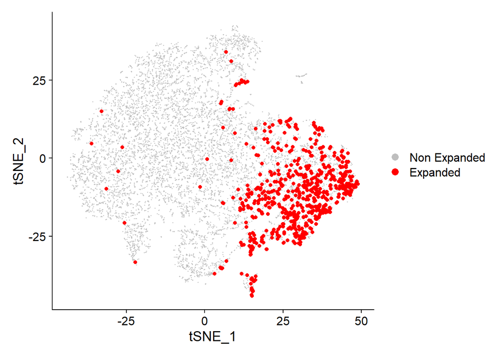

```r
tcr_folder <- "C:/Users/bh719/Dropbox (Partners HealthCare)/Sally and Jim/FeiData of scRNAseq  Treg project/10xProcessedData of day 7 after burn/12-13-multi/12-13_multi/outs/"
treg <- add_clonotype(tcr_folder,treg)
exp_cells <- WhichCells(treg, expression = Cell.State == 'Expanded')
DimPlot(treg, cells.highlight = exp_cells, reduction = 'tsne',sizes.highlight = 1.5,label.size = 12) + scale_color_manual(labels = c("Non Expanded","Expanded"),values = c("grey","red"))
```

Designate Expanded cell clusters, use 15% expanded cell representation as min cutoff

```r
exp_clusters <- FetchData(treg, vars = c('seurat_clusters'), cells = exp_cells)
x <- table(exp_clusters)
t <- table(treg$seurat_clusters)
exp_per <- x / t
exp_per
```

```
## exp_clusters
##           0           1           2           3           4           5
## 0.003089598 0.002074689 0.000000000 0.001324503 0.000000000 0.010380623
##           6           7           8           9          10          11
## 0.267889908 0.142592593 0.000000000 0.007984032 0.017204301 0.332613391
##          12          13          14          15          16          17
## 0.004640371 0.150417827 0.060975610 0.013422819 0.369718310 0.162361624
##          18          19          20          21          22          23
## 0.000000000 0.194029851 0.000000000 0.300000000 0.129629630 0.220000000
##          24
## 0.000000000
```

```r
exp_clust <- names(exp_per[exp_per > 0.15])
```

Define function to add meta data

```r
f_add_act_pheno <- function(s_obj, act_clusters){
  act_pheno <- data.frame(act_pheno = c())
  pb <- progress_bar$new(total = length(s_obj$seurat_clusters))
  for (i in 1:length(s_obj$seurat_clusters)){
    pb$tick()
    clust <- s_obj$seurat_clusters[[i]]
    if (clust %in% act_clusters){
      act_pheno <- rbind(act_pheno, data.frame(act_pheno = 'Expanded Phenotype'))
    } else {
      act_pheno <- rbind(act_pheno, data.frame(act_pheno = 'Unexpanded Phenotype'))
    }
  }
  rownames(act_pheno) <- names(s_obj$seurat_clusters)
  s_obj <- AddMetaData(object = s_obj, metadata = act_pheno)
}
```

Define function to set plot colors

```r
ggplotColours <- function(n = 6, h = c(0, 360) + 15){
  if ((diff(h) %% 360) < 1) h[2] <- h[2] - 360/n
  hcl(h = (seq(h[1], h[2], length = n)), c = 100, l = 65)
}
```

Add meta data and plot

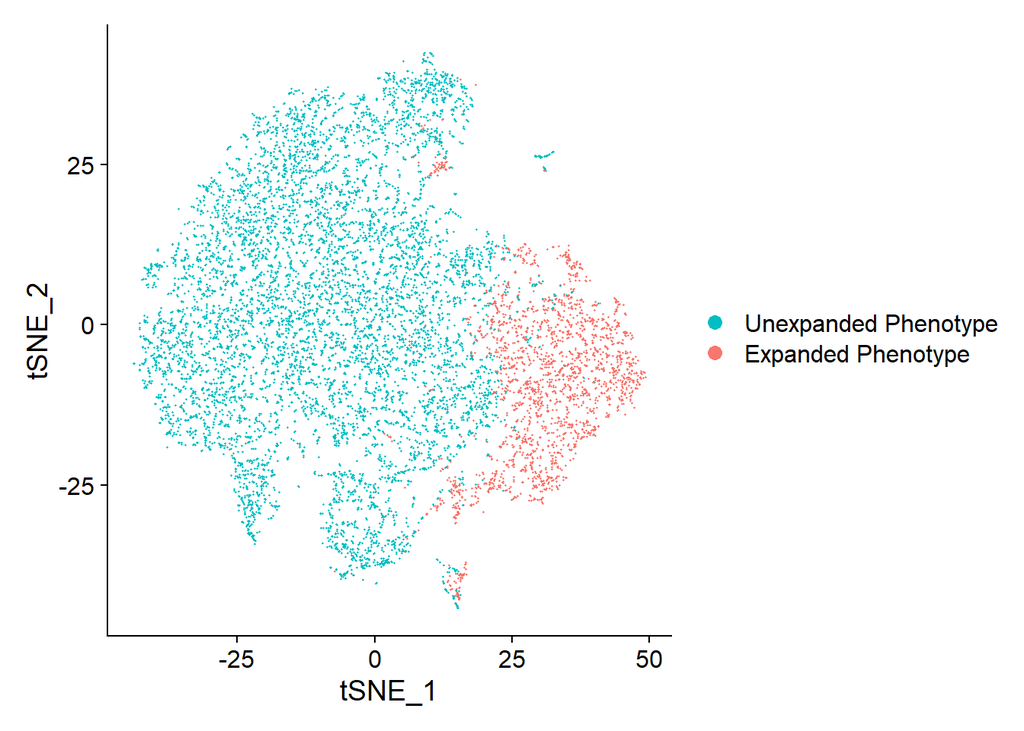

```r
#Classify clusters as expanded or non / active or not
treg <- f_add_act_pheno(treg, exp_clust)
Idents(treg) <- treg$act_pheno
DimPlot(treg, reduction = 'tsne',cols = rev(ggplotColours(2)))
```

Feature Plots

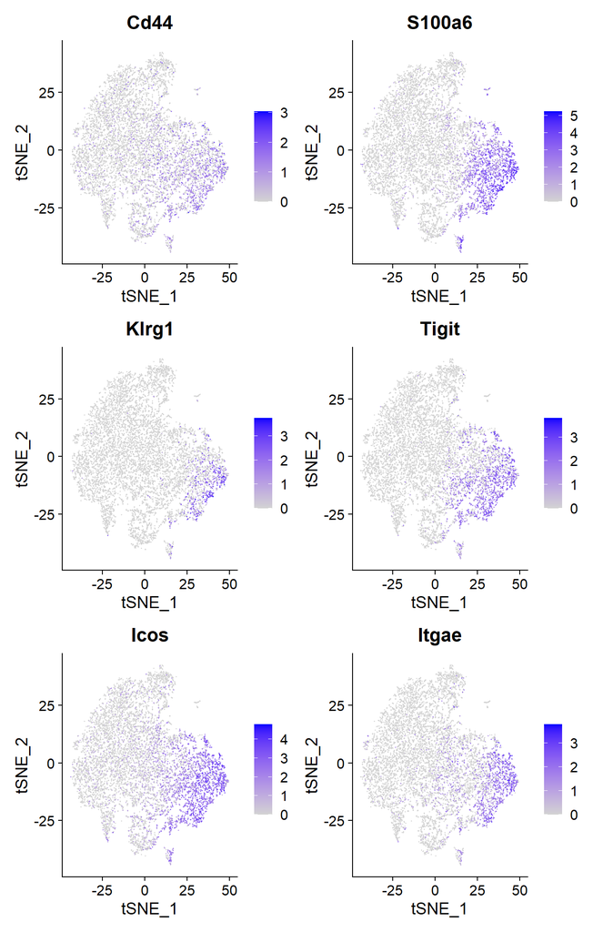

```r
FeaturePlot(treg, features = c('Cd44','S100a6','Klrg1','Tigit','Icos','Itgae'))
```

Session Info

```r
installed.packages()[names(sessionInfo()$otherPkgs), "Version"]
```

```
##      stringr      ggplot2     progress    patchwork SeuratObject       Seurat
##      "1.4.0"      "3.3.3"      "1.2.2"      "1.1.1"      "4.0.1"      "4.0.2"
##        dplyr
##      "1.0.5"
```